# Pertemuan 3 - Regresi dengan Peubah Lag

Delia Fitri Audina

## Data Yang Digunakan

Link : https://www.kaggle.com/datasets/ggsri123/co2-emissions-from-fossil-fuels

Judul : CO2 Emissions from Fossil Fuels

Negara : India

Tahun : 1960 - 2014

Variabel :

- X (variabel independen): Jumlah Bahan Bakar Padat Emisi karbon dari konsumsi bahan bakar padat
- Y (variabel dependen): Total emisi karbon dari konsumsi bahan bakar fosil dan produksi semen di India 1960-2014

## Impor Data

```r
library(readxl)
data <- read_excel("C:/Users/Delia/OneDrive/Documents/Data3.xlsx")
str(data)
```

```
## tibble [55 × 4] (S3: tbl_df/tbl/data.frame)
##  $ t     : num [1:55] 1 2 3 4 5 6 7 8 9 10 ...
##  $ Yt    : num [1:55] 32883 35561 39124 42019 41082 ...
##  $ Y(t-1): num [1:55] NA 32883 35561 39124 42019 ...
##  $ Xt    : num [1:55] 26509 28622 31150 33309 31952 ...
```

```r
data
```

```
## # A tibble: 55 × 4
##        t    Yt `Y(t-1)`    Xt
##    <dbl> <dbl>    <dbl> <dbl>
##  1     1 32883       NA 26509
##  2     2 35561    32883 28622
##  3     3 39124    35561 31150
##  4     4 42019    39124 33309
##  5     5 41082    42019 31952
##  6     6 45261    41082 35129
##  7     7 46841    45261 35289
##  8     8 46970    46841 35926
##  9     9 51087    46970 37353
## 10    10 52011    51087 37214
## # ℹ 45 more rows
```

## Pembagian Data

```r
#SPLIT DATA
train<-data[1:43,]
test<-data[44:55,]
```

```r
#data time series
train.ts<-ts(train)
test.ts<-ts(test)
data.ts<-ts(data)
```

## Model Koyck

```r
#MODEL KOYCK
model.koyck <- koyckDlm(x = train$Xt, y = train$Yt)
summary(model.koyck)
```

```
##
## Call:
## "Y ~ (Intercept) + Y.1 + X.t"
##
## Residuals:
##     Min      1Q  Median      3Q     Max
## -4920.8 -1071.7  -135.2   941.7  5693.1
##
## Coefficients:
##               Estimate Std. Error t value Pr(>|t|)
## (Intercept) -3.702e+03  1.383e+03  -2.677   0.0108 *
## Y.1          6.092e-01  9.765e-02   6.238 2.42e-07 ***
## X.t          6.821e-01  1.558e-01   4.377 8.73e-05 ***
## ---
## Signif. codes:  0 '***' 0.001 '**' 0.01 '*' 0.05 '.' 0.1 ' ' 1
##
## Residual standard error: 2133 on 39 degrees of freedom
## Multiple R-Squared: 0.9994,  Adjusted R-squared: 0.9993
## Wald test: 3.002e+04 on 2 and 39 DF,  p-value: < 2.2e-16
##
## Diagnostic tests:
## NULL
##
##                              alpha      beta      phi
## Geometric coefficients:  -9471.341 0.6820713 0.609172
```

```r
AIC(model.koyck)
```

```
## [1] 767.9556
```

```r
BIC(model.koyck)
```

```
## [1] 774.9063
```

Dari hasil tersebut, didapat bahwa peubah $x_t$ dan $y_{t-1}$ memiliki nilai $P-Value<0.05$. Hal ini menunjukkan bahwa peubah $x_t$ dan $y_{t-1}$ berpengaruh signifikan terhadap $y$. Adapun model keseluruhannya adalah sebagai berikut

$$\hat{Y_t}=-3702+0.6821X_t+0.6092Y_{t-1}$$

### Peramalan dan Akurasi

Berikut adalah hasil peramalan y untuk 12 periode kedepan menggunakan model koyck

```r
fore.koyck <- forecast(model = model.koyck, x=test$Xt, h=12)
fore.koyck
```

```
## $forecasts
##  [1] 300212.5 317026.7 337865.4 361278.5 389720.0 421101.9 455270.8 477036.4
##  [9] 512114.8 562303.8 586209.0 631056.0
##
## $call
## forecast.koyckDlm(model = model.koyck, x = test$Xt, h = 12)
##
## attr(,"class")
## [1] "forecast.koyckDlm" "dLagM"
```

```r
mape.koyck <- MAPE(fore.koyck$forecasts, test$Yt)
mape.koyck
```

```
## [1] 0.02141675
```

```r
#akurasi data training
GoF(model.koyck)
```

```
##              n      MAE          MPE       MAPE      sMAPE      MASE     MSE
## model.koyck 42 1504.232 -0.002218569 0.01349052 0.01342814 0.2429889 4224050
##                  MRAE     GMRAE
## model.koyck 0.8165828 0.2271073
```

Model koyck merupakan model yang sangat baik dengan nilai MAPE yang kurang dari 10%.

## Regression with Distributed Lag

### Pemodelan (Lag=2)

```r
model.dlm <- dlm(x = train$Xt,y = train$Yt , q = 2)
summary(model.dlm)
```

```
##
## Call:
## lm(formula = model.formula, data = design)
##
## Residuals:
##     Min      1Q  Median      3Q     Max
## -6509.7 -1235.5   160.9  1069.5  6636.6
##
## Coefficients:
##               Estimate Std. Error t value Pr(>|t|)
## (Intercept) -1.062e+04  7.970e+02 -13.330 1.07e-15 ***
## x.t          1.059e+00  1.519e-01   6.973 3.08e-08 ***
## x.1          2.382e-01  2.189e-01   1.088   0.2837
## x.2          3.928e-01  1.593e-01   2.465   0.0184 *
## ---
## Signif. codes:  0 '***' 0.001 '**' 0.01 '*' 0.05 '.' 0.1 ' ' 1
##
## Residual standard error: 2531 on 37 degrees of freedom
## Multiple R-squared:  0.9991, Adjusted R-squared:  0.999
## F-statistic: 1.38e+04 on 3 and 37 DF,  p-value: < 2.2e-16
##
## AIC and BIC values for the model:
##        AIC      BIC
## 1 764.7172 773.2851
```

```r
AIC(model.dlm)
```

```
## [1] 764.7172
```

```r
BIC(model.dlm)
```

```
## [1] 773.2851
```

$$\hat{Y_t}=-10620+1.059X_t+0.2382X_{t-1}+0.3928X_{t-2}$$

### Peramalan dan Akurasi

Berikut merupakan hasil peramalan $y$ untuk 12 periode kedepan

```r
fore.dlm <- forecast(model = model.dlm, x=test$Xt, h=12)
fore.dlm
```

```
## $forecasts
##  [1] 301289.4 319288.5 342140.3 367704.8 399563.4 432510.3 468953.1 483779.9
##  [9] 526656.4 579568.2 591843.9 653131.6
##
## $call
## forecast.dlm(model = model.dlm, x = test$Xt, h = 12)
##
## attr(,"class")
## [1] "forecast.dlm" "dLagM"
```

```r
mape.dlm <- MAPE(fore.dlm$forecasts, test$Yt)

#akurasi data training
GoF(model.dlm)
```

```
##            n      MAE           MPE       MAPE      sMAPE      MASE     MSE
## model.dlm 41 1761.723 -0.0008864786 0.01749313 0.01747886 0.2815953 5779691
##                MRAE     GMRAE
## model.dlm 0.9284178 0.2635729
```

### *Lag* Optimum

```r
#penentuan lag optimum
finiteDLMauto(formula = Yt ~ Xt,
              data = data.frame(train), q.min = 1, q.max = 15,
              model.type = "dlm", error.type = "AIC", trace = FALSE)
```

```
##    q - k    MASE      AIC      BIC   GMRAE    MBRAE R.Adj.Sq Ljung-Box
## 15    15 0.14036 520.4057 544.3853 0.11622 -0.09971  0.99914 0.1190441
```

Berdasarkan output tersebut, lag optimum didapatkan ketika lag=15. Selanjutnya dilakukan pemodelan untuk lag=15

```r
#model dlm dengan lag optimum
model.dlm2 <- dlm(x = train$Xt,y = train$Yt , q = 15)
summary(model.dlm2)
```

```
##
## Call:
## lm(formula = model.formula, data = design)
##
## Residuals:
##     Min      1Q  Median      3Q     Max
## -2742.4  -897.2  -145.2   911.5  2915.9
##
## Coefficients:
##               Estimate Std. Error t value Pr(>|t|)
## (Intercept) -1.006e+04  3.356e+03  -2.997   0.0121 *
## x.t          1.428e+00  1.991e-01   7.172 1.82e-05 ***
## x.1         -2.804e-02  2.609e-01  -0.107   0.9164
## x.2          2.559e-02  2.499e-01   0.102   0.9203
## x.3         -8.622e-02  2.464e-01  -0.350   0.7329
## x.4          3.153e-01  2.601e-01   1.212   0.2509
## x.5         -4.529e-01  3.454e-01  -1.311   0.2166
## x.6          1.896e-01  3.524e-01   0.538   0.6013
## x.7          1.415e-01  3.783e-01   0.374   0.7155
## x.8          1.992e-02  3.848e-01   0.052   0.9596
## x.9          6.018e-01  3.831e-01   1.571   0.1446
## x.10         7.389e-02  3.707e-01   0.199   0.8457
## x.11        -2.322e-01  3.447e-01  -0.674   0.5144
## x.12        -2.227e-01  3.469e-01  -0.642   0.5340
## x.13         1.214e-01  3.495e-01   0.347   0.7349
## x.14        -3.884e-01  3.542e-01  -1.096   0.2964
## x.15         1.827e-01  3.431e-01   0.532   0.6050
## ---
## Signif. codes:  0 '***' 0.001 '**' 0.01 '*' 0.05 '.' 0.1 ' ' 1
##
## Residual standard error: 2205 on 11 degrees of freedom
## Multiple R-squared:  0.9996, Adjusted R-squared:  0.9991
## F-statistic:  1953 on 16 and 11 DF,  p-value: < 2.2e-16
##
## AIC and BIC values for the model:
##        AIC      BIC
## 1 520.4057 544.3853
```

```r
AIC(model.dlm2)
```

```
## [1] 520.4057
```

```r
BIC(model.dlm2)
```

```
## [1] 544.3853
```

Adapun hasil peramalan 12 periode kedepan menggunakan model tersebut adalah sebagai berikut

```r
#peramalan dan akurasi
fore.dlm2 <- forecast(model = model.dlm2, x=test$Xt, h=12)
mape.dlm2<- MAPE(fore.dlm2$forecasts, test$Yt)
#akurasi data training
GoF(model.dlm2)
```

```
##             n      MAE           MPE        MAPE       sMAPE     MASE     MSE
## model.dlm2 28 1137.019 -0.0002409895 0.008931554 0.008936234 0.140358 1909449
##                 MRAE     GMRAE
## model.dlm2 0.2090141 0.1162181
```

Model tersebut merupakan model yang sangat baik dengan nilai MAPE yang kurang dari 10%.

## Model Autoregressive

### Pemodelan

```r
model.ardl <- ardlDlm(x = train$Xt, y = train$Yt, p = 1 , q = 1)
summary(model.ardl)
```

```
##
## Time series regression with "ts" data:
## Start = 2, End = 43
##
## Call:
## dynlm(formula = as.formula(model.text), data = data, start = 1)
##
## Residuals:
##     Min      1Q  Median      3Q     Max
## -4654.5  -814.8   -93.6   829.8  3996.8
##
## Coefficients:
##               Estimate Std. Error t value Pr(>|t|)
## (Intercept) -3.680e+03  1.166e+03  -3.157  0.00312 **
## X.t          1.132e+00  1.078e-01  10.499 8.67e-13 ***
## X.1         -5.271e-01  1.984e-01  -2.656  0.01149 *
## Y.1          6.461e-01  9.305e-02   6.943 2.93e-08 ***
## ---
## Signif. codes:  0 '***' 0.001 '**' 0.01 '*' 0.05 '.' 0.1 ' ' 1
##
## Residual standard error: 1789 on 38 degrees of freedom
## Multiple R-squared:  0.9996, Adjusted R-squared:  0.9995
## F-statistic: 2.847e+04 on 3 and 38 DF,  p-value: < 2.2e-16
```

```r
AIC(model.ardl)
```

```
## [1] 754.1049
```

```r
BIC(model.ardl)
```

```
## [1] 762.7933
```

```r
model.ardl <- ardlDlm(formula = Yt ~ Xt,
                         data = train,p = 1 , q = 1)
summary(model.ardl)
```

```
##
## Time series regression with "ts" data:
## Start = 2, End = 43
##
## Call:
## dynlm(formula = as.formula(model.text), data = data)
##
## Residuals:
##     Min      1Q  Median      3Q     Max
## -4654.5  -814.8   -93.6   829.8  3996.8
##
## Coefficients:
##               Estimate Std. Error t value Pr(>|t|)
## (Intercept) -3.680e+03  1.166e+03  -3.157  0.00312 **
## Xt.t         1.132e+00  1.078e-01  10.499 8.67e-13 ***
## Xt.1        -5.271e-01  1.984e-01  -2.656  0.01149 *
## Yt.1         6.461e-01  9.305e-02   6.943 2.93e-08 ***
## ---
## Signif. codes:  0 '***' 0.001 '**' 0.01 '*' 0.05 '.' 0.1 ' ' 1
##
## Residual standard error: 1789 on 38 degrees of freedom
## Multiple R-squared:  0.9996, Adjusted R-squared:  0.9995
## F-statistic: 2.847e+04 on 3 and 38 DF,  p-value: < 2.2e-16
```

```r
AIC(model.ardl)
```

```
## [1] 754.1049
```

```r
BIC(model.ardl)
```

```
## [1] 762.7933
```

Hasil uji t di atas menunjukkan bahwa peubah $x_t$, $x_{t-1}$, dan $y_{t-1}$ memiliki nilai-p pada peubah $<0.05$ Hal ini menunjukkan bahwa peubah $x_{t-1}$,$x_t$, dan $y_{t-1}$ berpengaruh signifikan terhadap $y_t$. Model keseluruhannya adalah sebagai berikut:

$$\hat{Y}=-3680+1.132X_t-0.5271X_{t-1}+0.6461Y_{t-1}$$

### Peramalan dan Akurasi

```r
fore.ardl <- forecast(model = model.ardl, x=test$Xt, h=12)
fore.ardl
```

```
## $forecasts
##  [1] 300663.5 319884.5 342883.4 367347.5 398407.0 430850.1 465935.1 478550.5
##  [9] 522185.5 581357.0 586247.5 644831.0
##
## $call
## forecast.ardlDlm(model = model.ardl, x = test$Xt, h = 12)
##
## attr(,"class")
## [1] "forecast.ardlDlm" "dLagM"
```

Data di atas merupakan hasil peramalan untuk 12 periode ke depan menggunakan Model Autoregressive dengan $p=1$ dan $q=1$.

```r
mape.ardl <- MAPE(fore.ardl$forecasts, test$Yt)
mape.ardl
```

```
## [1] 0.03102557
```

```r
#akurasi data training
GoF(model.ardl)
```

```
##             n      MAE           MPE       MAPE      sMAPE      MASE     MSE
## model.ardl 42 1257.391 -0.0007615238 0.01105025 0.01104016 0.2031151 2896192
##                 MRAE    GMRAE
## model.ardl 0.5860082 0.176843
```

Berdasarkan akurasi di atas, terlihat bahwa nilai MAPE keduanya tidak jauh berbeda. Artinya, model regresi dengan distribusi lag ini tidak `overfitted` atau `underfitted`

### *Lag* Optimum

```r
#penentuan lag optimum
model.ardl.opt <- ardlBoundOrders(data = data.frame(data), ic = "AIC",
                                  formula = Yt ~ Xt )
model.ardl.opt
```

```
## $p
##   Xt
## 1 15
##
## $q
## [1] 15
##
## $Stat.table
##            q = 1     q = 2     q = 3    q = 4    q = 5    q = 6    q = 7
## p = 1  1036.9358 1020.0244 1000.4965 983.6999 960.8849 944.3886 922.2499
## p = 2  1020.4741 1021.0277 1002.4948 985.6961 962.8849 946.3838 923.9968
## p = 3  1001.8760 1001.8760 1003.7316 987.3114 964.3062 947.7629 924.6146
## p = 4   982.2058  983.9186  983.9186 982.4613 963.2293 946.8001 923.8556
## p = 5   960.1417  962.1269  964.1044 964.1044 965.1967 948.7229 925.6335
## p = 6   942.8258  944.8221  946.8212 948.8198 948.8198 950.7108 927.6324
## p = 7   922.6949  924.5068  926.1594 928.0181 929.9169 929.9169 929.3526
## p = 8   905.4047  906.7275  908.5817 910.5710 912.3382 912.9564 912.9564
## p = 9   874.9794  875.7016  877.5851 878.1328 878.0422 879.8636 878.4073
## p = 10  855.0196  856.6947  858.6494 859.9847 860.1006 861.7524 858.0976
## p = 11  839.0625  841.0450  842.0375 842.3439 842.5092 843.6367 841.8851
## p = 12  810.8959  812.8955  814.6602 811.5551 810.6927 812.5151 814.4125
## p = 13  786.6572  785.8653  787.8175 786.8180 785.2882 785.6192 786.6443
## p = 14  765.0155  765.1199  766.8490 756.5879 758.4846 760.1365 762.0266
## p = 15  749.4090  746.3143  748.3103 733.6037 734.7475 736.6516 737.4183
##           q = 8    q = 9   q = 10   q = 11   q = 12   q = 13   q = 14   q = 15
## p = 1  906.0172 868.4312 849.2423 833.2260 808.6465 781.4112 758.8986 736.6354
## p = 2  907.7728 869.7940 851.1993 835.2143 810.4787 781.3778 758.9511 735.3528
## p = 3  908.4666 871.5869 853.1309 837.0907 812.3152 783.1035 760.8522 737.3120
## p = 4  907.3847 873.1889 854.3367 838.3787 814.2615 784.7586 762.8464 738.0413
## p = 5  909.1524 875.1125 855.8922 839.6849 815.7647 784.4083 763.3132 733.2967
## p = 6  911.1484 877.0634 857.8778 841.6836 817.7584 786.3887 763.9056 733.8759
## p = 7  912.8767 878.3870 859.4062 843.4117 819.7005 787.8310 764.8122 735.2824
## p = 8  912.3765 878.2741 859.7813 843.5874 819.8780 782.0595 757.3729 729.0892
## p = 9  878.4073 879.1136 860.7233 844.7711 821.3312 779.5632 756.8907 730.4970
## p = 10 859.9166 859.9166 861.9112 845.9273 823.0471 778.9365 756.6073 732.0276
## p = 11 843.8828 845.5251 845.5251 846.3236 823.7160 780.0567 757.8695 733.5861
## p = 12 814.9159 816.9146 818.9144 818.9144 820.7189 771.4675 751.5818 720.8367
## p = 13 788.2555 787.7323 788.7266 790.3931 790.3931 772.2190 753.0374 721.7636
## p = 14 763.8177 765.3126 765.5569 766.5282 754.8925 754.8925 750.7790 720.4087
## p = 15 739.3852 741.1544 742.7552 742.7614 719.9135 715.7089 715.7089 717.7089
##
## $min.Stat
## [1] 715.7089
```

```r
min_p=c()
for(i in 1:15){
  min_p[i]=min(model.ardl.opt$Stat.table[[i]])
}
q_opt=which(min_p==min(min_p, na.rm = TRUE))
p_opt=which(model.ardl.opt$Stat.table[[q_opt]] ==
              min(model.ardl.opt$Stat.table[[q_opt]], na.rm = TRUE))
data.frame("q_optimum" = q_opt, "p_optimum" = p_opt,
           "AIC"=model.ardl.opt$min.Stat)
```

```
##   q_optimum p_optimum      AIC
## 1        13         1 715.7089
## 2        14         1 715.7089
```

## Pemodelan DLM & ARDL dengan Library `dynlm`

```r
#sama dengan model dlm q=1
cons_lm1 <- dynlm(Yt ~ Xt+L(Xt),data = train.ts)
#sama dengan model ardl p=1 q=0
cons_lm2 <- dynlm(Yt ~ Xt+L(Yt),data = train.ts)
#sama dengan ardl p=1 q=1
cons_lm3 <- dynlm(Yt ~ Xt+L(Xt)+L(Yt),data = train.ts)
#sama dengan dlm p=2
cons_lm4 <- dynlm(Yt ~ Xt+L(Xt)+L(Xt,2),data = train.ts)
```

### Ringkasan Model

```r
summary(cons_lm1)
```

```
##
## Time series regression with "ts" data:
## Start = 2, End = 43
##
## Call:
## dynlm(formula = Yt ~ Xt + L(Xt), data = train.ts)
##
## Residuals:
##     Min      1Q  Median      3Q     Max
## -6641.2 -1158.0  -349.7  1569.7  5976.8
##
## Coefficients:
##               Estimate Std. Error t value Pr(>|t|)
## (Intercept) -1.083e+04  8.134e+02 -13.309 4.40e-16 ***
## Xt           1.061e+00  1.596e-01   6.648 6.55e-08 ***
## L(Xt)        6.135e-01  1.655e-01   3.707 0.000651 ***
## ---
## Signif. codes:  0 '***' 0.001 '**' 0.01 '*' 0.05 '.' 0.1 ' ' 1
##
## Residual standard error: 2660 on 39 degrees of freedom
## Multiple R-squared:  0.999,  Adjusted R-squared:  0.9989
## F-statistic: 1.931e+04 on 2 and 39 DF,  p-value: < 2.2e-16
```

```r
summary(cons_lm2)
```

```
##
## Time series regression with "ts" data:
## Start = 2, End = 43
##
## Call:
## dynlm(formula = Yt ~ Xt + L(Yt), data = train.ts)
##
## Residuals:
##     Min      1Q  Median      3Q     Max
## -5081.1  -820.5   -68.6   704.7  4182.1
##
## Coefficients:
##               Estimate Std. Error t value Pr(>|t|)
## (Intercept) -5.841e+03  8.971e+02  -6.511 1.01e-07 ***
## Xt           9.499e-01  8.941e-02  10.624 4.48e-13 ***
## L(Yt)        4.415e-01  5.611e-02   7.869 1.42e-09 ***
## ---
## Signif. codes:  0 '***' 0.001 '**' 0.01 '*' 0.05 '.' 0.1 ' ' 1
##
## Residual standard error: 1923 on 39 degrees of freedom
## Multiple R-squared:  0.9995, Adjusted R-squared:  0.9994
## F-statistic: 3.697e+04 on 2 and 39 DF,  p-value: < 2.2e-16
```

```r
summary(cons_lm3)
```

```
##
## Time series regression with "ts" data:
## Start = 2, End = 43
##
## Call:
## dynlm(formula = Yt ~ Xt + L(Xt) + L(Yt), data = train.ts)
##
## Residuals:
##     Min      1Q  Median      3Q     Max
## -4654.5  -814.8   -93.6   829.8  3996.8
##
## Coefficients:
##               Estimate Std. Error t value Pr(>|t|)
## (Intercept) -3.680e+03  1.166e+03  -3.157  0.00312 **
## Xt           1.132e+00  1.078e-01  10.499 8.67e-13 ***
## L(Xt)       -5.271e-01  1.984e-01  -2.656  0.01149 *
## L(Yt)        6.461e-01  9.305e-02   6.943 2.93e-08 ***
## ---
## Signif. codes:  0 '***' 0.001 '**' 0.01 '*' 0.05 '.' 0.1 ' ' 1
##
## Residual standard error: 1789 on 38 degrees of freedom
## Multiple R-squared:  0.9996, Adjusted R-squared:  0.9995
## F-statistic: 2.847e+04 on 3 and 38 DF,  p-value: < 2.2e-16
```

```r
summary(cons_lm4)
```

```
##
## Time series regression with "ts" data:
## Start = 3, End = 43
##
## Call:
## dynlm(formula = Yt ~ Xt + L(Xt) + L(Xt, 2), data = train.ts)
##
## Residuals:
##     Min      1Q  Median      3Q     Max
## -6509.7 -1235.5   160.9  1069.5  6636.6
##
## Coefficients:
##               Estimate Std. Error t value Pr(>|t|)
## (Intercept) -1.062e+04  7.970e+02 -13.330 1.07e-15 ***
## Xt           1.059e+00  1.519e-01   6.973 3.08e-08 ***
## L(Xt)        2.382e-01  2.189e-01   1.088   0.2837
## L(Xt, 2)     3.928e-01  1.593e-01   2.465   0.0184 *
## ---
## Signif. codes:  0 '***' 0.001 '**' 0.01 '*' 0.05 '.' 0.1 ' ' 1
##
## Residual standard error: 2531 on 37 degrees of freedom
## Multiple R-squared:  0.9991, Adjusted R-squared:  0.999
## F-statistic: 1.38e+04 on 3 and 37 DF,  p-value: < 2.2e-16
```

Dari uji diatas didapatkan model terbaik dari segi kemampuan menjelaskan variasi dalam $Y_t$ dan akurasi prediksi adalah Model 3 (ARDL dengan p=1 dan q=1) yang memiliki nilai Multiple R-squared tertinggi dan Residual standard error terendah. Model ini juga menunjukkan bahwa baik variabel saat ini $X_t$, lag pertama di $X_t$, dan lag pertama dari $Y_t$ berpengaruh signifikan terhadap variabel dependen $Y_t$.

### SSE

```r
deviance(cons_lm1)
```

```
## [1] 275959743
```

```r
deviance(cons_lm2)
```

```
## [1] 144224675
```

```r
deviance(cons_lm3)
```

```
## [1] 121640063
```

```r
deviance(cons_lm4)
```

```
## [1] 236967311
```

Model 3 adalah yang terbaik untuk digunakan karena nilai SSE-nya paling kecil, yang berarti lebih akurat dalam memprediksi nilai yang sebenarnya dibandingkan model-model lainnya.

```r
#uji model
if(require("lmtest")) encomptest(cons_lm1, cons_lm2)
```

```
## Encompassing test
##
## Model 1: Yt ~ Xt + L(Xt)
## Model 2: Yt ~ Xt + L(Yt)
## Model E: Yt ~ Xt + L(Xt) + L(Yt)
##           Res.Df Df       F    Pr(>F)
## M1 vs. ME     38 -1 48.2090 2.935e-08 ***
## M2 vs. ME     38 -1  7.0554   0.01149 *
## ---
## Signif. codes:  0 '***' 0.001 '**' 0.01 '*' 0.05 '.' 0.1 ' ' 1
```

Hasil uji model diatas menunjukkan bahwa kedua model(Model 1 dan Model 2) berbeda signifikan dibandingkan dengan model yang lebih umum (Model E).Namun, Model 2 sedikit lebih baik dibandingkan Model 1, karena memiliki nilai F yang lebih rendah dan p-value yang lebih tinggi, meskipun tetap signifikan.

#### Autokorelasi

```r
#durbin watson
dwtest(cons_lm1)
```

```
##
##  Durbin-Watson test
##
## data:  cons_lm1
## DW = 0.70546, p-value = 1.858e-07
## alternative hypothesis: true autocorrelation is greater than 0
```

```r
dwtest(cons_lm2)
```

```
##
##  Durbin-Watson test
##
## data:  cons_lm2
## DW = 1.302, p-value = 0.003998
## alternative hypothesis: true autocorrelation is greater than 0
```

```r
dwtest(cons_lm3)
```

```
##
##  Durbin-Watson test
##
## data:  cons_lm3
## DW = 1.5665, p-value = 0.04131
## alternative hypothesis: true autocorrelation is greater than 0
```

```r
dwtest(cons_lm4)
```

```
##
##  Durbin-Watson test
##
## data:  cons_lm4
## DW = 0.75679, p-value = 1.202e-06
## alternative hypothesis: true autocorrelation is greater than 0
```

Berdasarkan hasil uji Durbin-Watson Semua model menunjukkan adanya autokorelasi positif, dengan tingkat autokorelasi tertinggi di Model 1 dan Model 4.

#### Heterogenitas

```r
bptest(cons_lm1)
```

```
##
##  studentized Breusch-Pagan test
##
## data:  cons_lm1
## BP = 9.0084, df = 2, p-value = 0.01106
```

```r
bptest(cons_lm2)
```

```
##
##  studentized Breusch-Pagan test
##
## data:  cons_lm2
## BP = 12.729, df = 2, p-value = 0.001722
```

```r
bptest(cons_lm3)
```

```
##
##  studentized Breusch-Pagan test
##
## data:  cons_lm3
## BP = 15.306, df = 3, p-value = 0.001573
```

```r
bptest(cons_lm4)
```

```
##
##  studentized Breusch-Pagan test
##
## data:  cons_lm4
## BP = 6.8443, df = 3, p-value = 0.07703
```

Dari Uji Breusch-Pagan didapatkan hasil: Model 1, 2, dan 3 menunjukkan adanya heteroskedastisitas yang signifikan, yang berarti model tersebut memiliki masalah dengan varians residual yang tidak konstan. Model 4 tidak menunjukkan heteroskedastisitas yang signifikan, sehingga ini merupakan model yang lebih baik dalam hal kestabilan varians residual dibandingkan model lainnya.

#### Kenormalan

```r
shapiro.test(residuals(cons_lm1))
```

```
##
##  Shapiro-Wilk normality test
##
## data:  residuals(cons_lm1)
## W = 0.96604, p-value = 0.2418
```

```r
shapiro.test(residuals(cons_lm2))
```

```
##
##  Shapiro-Wilk normality test
##
## data:  residuals(cons_lm2)
## W = 0.96215, p-value = 0.1762
```

```r
shapiro.test(residuals(cons_lm3))
```

```
##
##  Shapiro-Wilk normality test
##
## data:  residuals(cons_lm3)
## W = 0.96924, p-value = 0.3114
```

```r
shapiro.test(residuals(cons_lm4))
```

```
##
##  Shapiro-Wilk normality test
##
## data:  residuals(cons_lm4)
## W = 0.95819, p-value = 0.1359
```

Dari uji shapiro-wilk didapatkan hasil untuk semua model (cons_lm1, cons_lm2, cons_lm3, cons_lm4), p-value > 0.05, yang berarti tidak ada bukti signifikan untuk menolak hipotesis bahwa residual berdistribusi normal. Oleh karena itu, kita dapat menyimpulkan bahwa residual dari keempat model berdistribusi normal.

## Perbandingan Model

```r
akurasi <- matrix(c(mape.koyck, mape.dlm, mape.dlm2, mape.ardl))
row.names(akurasi)<- c("Koyck","DLM 1","DLM 2","Autoregressive")
colnames(akurasi) <- c("MAPE")
akurasi
```

```
##                      MAPE
## Koyck          0.02141675
## DLM 1          0.03435775
## DLM 2          0.03393726
## Autoregressive 0.03102557
```

Berdasarkan nilai MAPE, model paling optimum didapat pada Model Koyck karena memiliki nilai MAPE yang terkecil.

### Plot

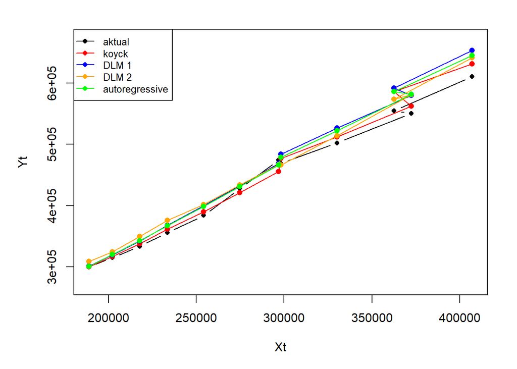

```r
# Mengatur margin agar grafik tidak terlalu mepet dengan garis pinggir
par(mfrow=c(1,1), mar=c(5, 5, 2, 2))  # Adjust the bottom, left, top, and right margins

# Membuat plot dengan skala Y yang diperluas dan tidak terlalu dekat dengan garis pinggir
plot(test$Xt, test$Yt, type="b", col="black", ylim=c(min(test$Yt)*0.9, max(test$Yt)*1.1),
     xlab="Xt", ylab="Yt", pch=16, cex=0.8)

# Menambahkan garis prediksi dari model
points(test$Xt, fore.koyck$forecasts, col="red", pch=16)
lines(test$Xt, fore.koyck$forecasts, col="red")
points(test$Xt, fore.dlm$forecasts, col="blue", pch=16)
lines(test$Xt, fore.dlm$forecasts, col="blue")
points(test$Xt, fore.dlm2$forecasts, col="orange", pch=16)
lines(test$Xt, fore.dlm2$forecasts, col="orange")
points(test$Xt, fore.ardl$forecasts, col="green", pch=16)
lines(test$Xt, fore.ardl$forecasts, col="green")

# Menambahkan legenda tanpa memperbesar ukurannya
legend("topleft", c("aktual", "koyck", "DLM 1", "DLM 2", "autoregressive"),
       lty=1, col=c("black","red","blue","orange","green"), cex=0.8, pch=16)
```

Berdasarkan plot tersebut, terlihat bahwa plot yang paling mendekati data aktualnya adalah Model koyck, sehingga dapat disimpulkan model terbaik dalam hal ini adalah model regresi koyck.